# Prueba modelo predictivo (8 de Mayo a 15 de Mayo)

Todo modelo predictivo debe probarse con datos reales, para determinar su validez. Una forma de medir el grado de error es el error medio cuadrático, que se calcula

$$EMC= \sum_i^k \frac{(y_i-\hat{y_i})^2}{n}$$

Donde $y_i$ es el dato observado en el momento $i$, en tanto que $\hat{y_i}$ es valor predicho. En nuestros ejemplos, como se calculará el EMC sobre los valores al logaritmo.

## Modelos de casos totales

Probaremos la adecuación de los tres modelos, que usamos hasta el momento - general cuadrático + AR(1), casos nuevos + AR(1), casos nuevos + AR(4), usando el modelo calculado el día [8 de Mayo](https://rpubs.com/clbustos/611478).

Se debe considerar que como los reportes del MINSAL se realizan con un día de retraso, realmente estamos usando los datos del día 7 de Mayo para predecir hasta el 14.

| inicio | final |
| --- | --- |
| 2020-05-07 | 2020-05-14 |

A diferencia de la prueba anterior del modelo, el modelo cuadrático ha funcionado bastante mal, estando fuera del intervalo de confianza 4 de los 7 días. El modelo de T+AR(1), muy similar al cuadrático, al menos mantiene el intervalo de confianza. El modelo T+AR(4) funcionó muy bien los primeros 4 días, hasta el aumento repentino de casos los últimos 3 días, pero igual se mantiene el intervalo de confianza.

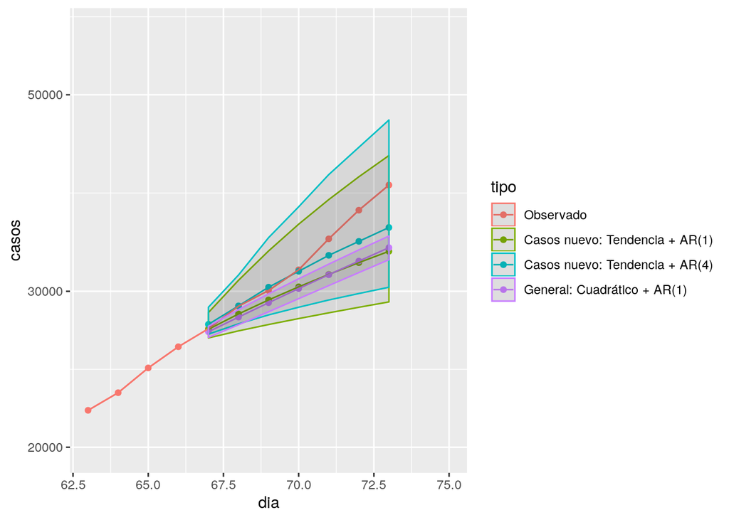

El MSE de T+AR(4) es menor al de T+AR(1) y el modelo cuadrático, lo contrario a lo que ocurrió en la prueba anterior.

| T.AR.1. | T.AR.4. | Cuadrático |
| --- | --- | --- |
| 0.008538148 | 0.002971291 | 0.008136113 |

¿Qué pasaría si hubiesemos considerado solo desde el caso 250 en adelante, como hace un mes? Se puede ver que tanto T+AR(1) y T+AR(4) se habrían comportado bien, mientras el modelo cuadrático habría subestimado todo el tiempo.

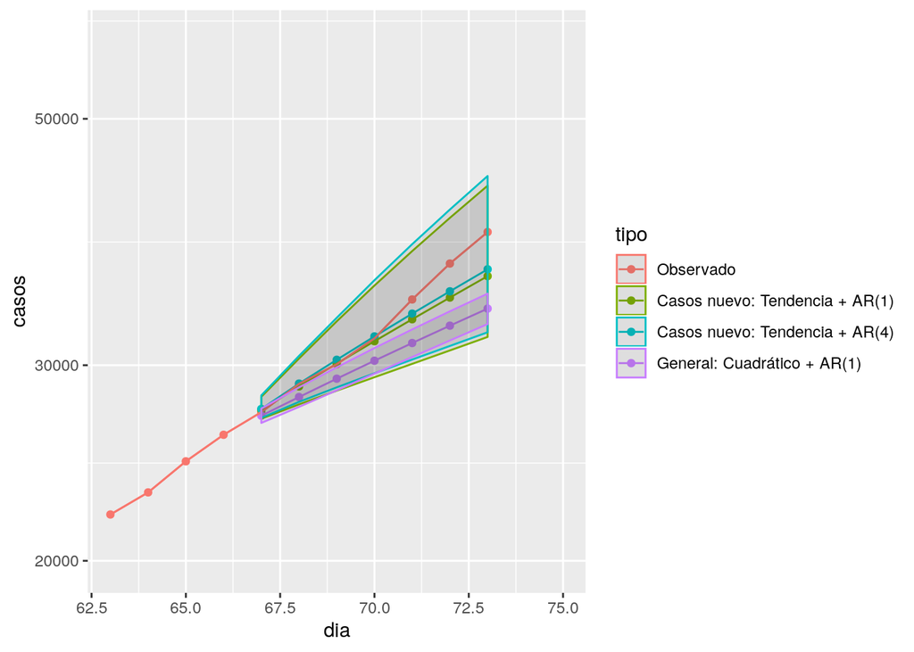

| T.AR.1. | T.AR.4. | Cuadrático |
| --- | --- | --- |
| 0.00215805 | 0.001470091 | 0.008136113 |

Si utilizamos el corte del periodo anterior, con 20 casos, el modelo T+AR(4) nuevamente funciona bastante bien, en tanto que T+AR(1) y el cuadrático subestiman de forma sistemática.

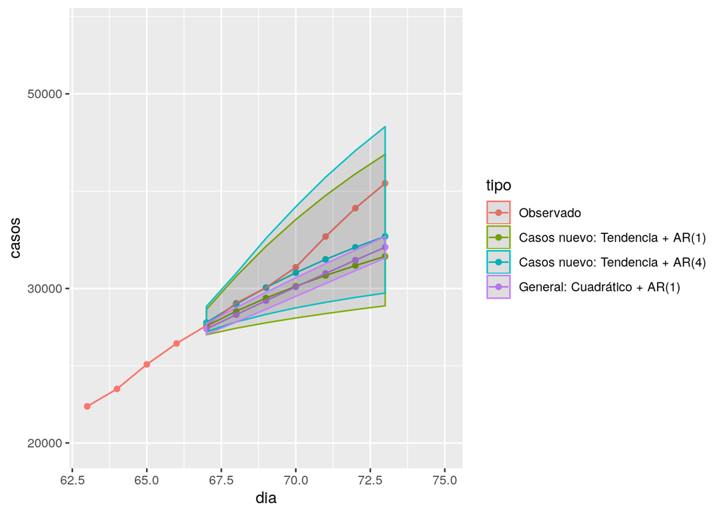

Los errores son mayores a los de cortar a los 50 o 250 casos.

| T.AR.1. | T.AR.4. | Cuadrático |
| --- | --- | --- |
| 0.01051591 | 0.004832117 | 0.008710894 |

## Predicción por regiones

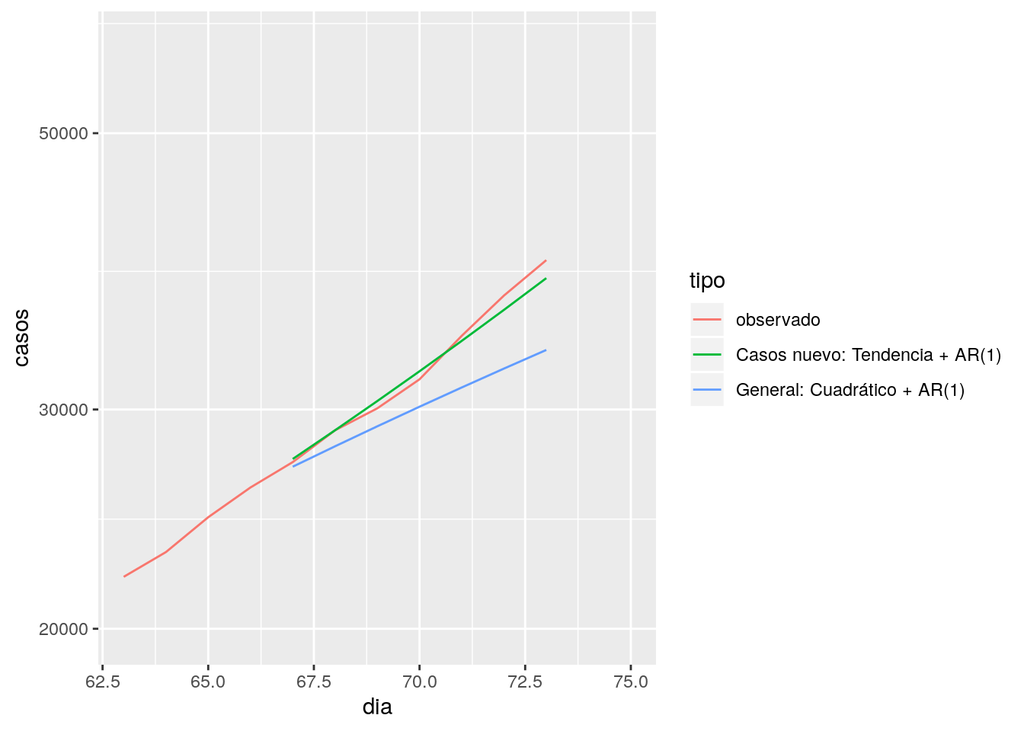

| Suma.regional.T.AR.1. | Suma.regional.Lineal.cuadrático |
| --- | --- |
| 0.0003334509 | 0.008512052 |

## Conclusión

Tras 3 evaluaciones de modelos, destaca la ventaja de tener varios algoritmos, ya que algunos funcionan mejor cuando el proceso no experimenta cambios bruscos (cuadrático), en cambio otros no siempre son óptimos por semana, pero aparecen como buenas estrategias porque nunca son muy malos (T+AR(4)). El claro ganador es el modelo de suma regional, que en las dos últimas pruebas ha logrado acercarse mucho a la sumatoria total, lo que refleja la importancia de analizar los procesos a nivel local.